# CHU_H Final Project Step Four Modeling And Evaluation

These are the libraries we are going to use for this step

```r
library(caTools)
library(FNN)
library(caret)
```

We first load the data we obtained from data preparation

```r
well.shaped.dataframe <- read.csv("AprilBeatmapDataWellShaped.csv")
```

Before we move on to training a model, we should take out the outliers we noticed during our data exploration phase.

```r
outlier.dataframe <- read.csv("outliers.csv")
outlier.beatmap_id <- outlier.dataframe$beatmap_id
well.shaped.dataframe.no.outlier <- subset(well.shaped.dataframe, !(beatmap_id %in% outlier.beatmap_id))
well.shaped.dataframe.no.outlier
```

|  | beatmapset_id | beatmap_id | hit_length | diff_size | diff_overall | diff_approach | diff_drain | max_combo | difficultyrating | bpm | favourite_count | approved_ranked | genre_anime | genre_pop | language_japanese | playcount_per_day |
| --- | --- | --- | --- | --- | --- | --- | --- | --- | --- | --- | --- | --- | --- | --- | --- | --- |
| 1 | 701681 | 1529054 | 215 | 3.0 | 3.0 | 5.0 | 3.0 | 511 | 1.523502 | 115.000 | 0 | 0 | 0 | 0 | 0 | 1.80000 |
| 2 | 693750 | 1475927 | 224 | 3.1 | 2.0 | 3.0 | 2.0 | 684 | 1.490454 | 182.000 | 21 | 0 | 0 | 0 | 1 | 2.25000 |
| 3 | 701681 | 1517442 | 215 | 3.5 | 5.0 | 6.5 | 4.0 | 653 | 2.592210 | 115.000 | 0 | 0 | 0 | 0 | 0 | 5.40000 |
| 4 | 734190 | 1569780 | 109 | 3.5 | 4.0 | 5.0 | 4.0 | 412 | 2.320535 | 210.000 | 12 | 0 | 0 | 0 | 0 | 6.75000 |
| 5 | 734190 | 1603225 | 113 | 2.8 | 2.0 | 3.0 | 3.0 | 323 | 1.659627 | 210.000 | 12 | 0 | 0 | 0 | 0 | 6.75000 |
| 6 | 693750 | 1468455 | 225 | 3.0 | 4.0 | 5.0 | 3.0 | 892 | 2.183076 | 182.000 | 21 | 0 | 0 | 0 | 1 | 6.75000 |
| 7 | 708148 | 1576393 | 173 | 2.5 | 3.0 | 3.0 | 3.0 | 284 | 1.501699 | 78.000 | 1 | 0 | 0 | 0 | 0 | 9.00000 |
| 8 | 676178 | 1442134 | 32 | 3.0 | 2.0 | 3.0 | 3.0 | 97 | 1.477244 | 171.000 | 0 | 0 | 1 | 0 | 0 | 7.20000 |
| 9 | 676178 | 1448179 | 32 | 3.5 | 4.0 | 5.0 | 4.0 | 120 | 2.066566 | 171.000 | 0 | 0 | 1 | 0 | 0 | 7.20000 |
| 10 | 545150 | 1585607 | 232 | 3.0 | 3.0 | 3.0 | 2.0 | 556 | 1.527961 | 160.000 | 2 | 0 | 0 | 0 | 1 | 9.00000 |

[output cut: 483 more lines]

```r
set.seed(04172018)
sample <- sample.split(well.shaped.dataframe.no.outlier, SplitRatio = .9)
well.shaped.dataframe.no.outlier.train <- subset(well.shaped.dataframe.no.outlier, sample == TRUE)
well.shaped.dataframe.no.outlier.validation <- subset(well.shaped.dataframe.no.outlier, sample == FALSE)
well.shaped.dataframe.no.outlier.train
```

|  | beatmapset_id | beatmap_id | hit_length | diff_size | diff_overall | diff_approach | diff_drain | max_combo | difficultyrating | bpm | favourite_count | approved_ranked | genre_anime | genre_pop | language_japanese | playcount_per_day |
| --- | --- | --- | --- | --- | --- | --- | --- | --- | --- | --- | --- | --- | --- | --- | --- | --- |
| 1 | 701681 | 1529054 | 215 | 3.0 | 3.0 | 5.0 | 3.0 | 511 | 1.523502 | 115.000 | 0 | 0 | 0 | 0 | 0 | 1.80000 |
| 2 | 693750 | 1475927 | 224 | 3.1 | 2.0 | 3.0 | 2.0 | 684 | 1.490454 | 182.000 | 21 | 0 | 0 | 0 | 1 | 2.25000 |
| 4 | 734190 | 1569780 | 109 | 3.5 | 4.0 | 5.0 | 4.0 | 412 | 2.320535 | 210.000 | 12 | 0 | 0 | 0 | 0 | 6.75000 |
| 5 | 734190 | 1603225 | 113 | 2.8 | 2.0 | 3.0 | 3.0 | 323 | 1.659627 | 210.000 | 12 | 0 | 0 | 0 | 0 | 6.75000 |
| 6 | 693750 | 1468455 | 225 | 3.0 | 4.0 | 5.0 | 3.0 | 892 | 2.183076 | 182.000 | 21 | 0 | 0 | 0 | 1 | 6.75000 |
| 7 | 708148 | 1576393 | 173 | 2.5 | 3.0 | 3.0 | 3.0 | 284 | 1.501699 | 78.000 | 1 | 0 | 0 | 0 | 0 | 9.00000 |
| 8 | 676178 | 1442134 | 32 | 3.0 | 2.0 | 3.0 | 3.0 | 97 | 1.477244 | 171.000 | 0 | 0 | 1 | 0 | 0 | 7.20000 |
| 9 | 676178 | 1448179 | 32 | 3.5 | 4.0 | 5.0 | 4.0 | 120 | 2.066566 | 171.000 | 0 | 0 | 1 | 0 | 0 | 7.20000 |
| 10 | 545150 | 1585607 | 232 | 3.0 | 3.0 | 3.0 | 2.0 | 556 | 1.527961 | 160.000 | 2 | 0 | 0 | 0 | 1 | 9.00000 |
| 11 | 742085 | 1566726 | 102 | 3.0 | 4.0 | 5.5 | 3.0 | 352 | 1.872148 | 155.000 | 3 | 0 | 0 | 0 | 1 | 12.00000 |

[output cut: 421 more lines]

```r
well.shaped.dataframe.no.outlier.validation
```

|  | beatmapset_id | beatmap_id | hit_length | diff_size | diff_overall | diff_approach | diff_drain | max_combo | difficultyrating | bpm | favourite_count | approved_ranked | genre_anime | genre_pop | language_japanese | playcount_per_day |
| --- | --- | --- | --- | --- | --- | --- | --- | --- | --- | --- | --- | --- | --- | --- | --- | --- |
| 3 | 701681 | 1517442 | 215 | 3.5 | 5.0 | 6.5 | 4.0 | 653 | 2.592210 | 115.000 | 0 | 0 | 0 | 0 | 0 | 5.40000 |
| 12 | 594067 | 1396904 | 113 | 3.0 | 2.0 | 3.0 | 2.0 | 318 | 1.540548 | 178.000 | 22 | 0 | 0 | 1 | 1 | 9.00000 |
| 19 | 693750 | 1479714 | 228 | 4.5 | 9.0 | 9.0 | 7.5 | 1271 | 5.862358 | 182.000 | 21 | 0 | 0 | 0 | 1 | 15.75000 |
| 28 | 705769 | 1500649 | 116 | 3.3 | 3.0 | 2.0 | 2.0 | 314 | 1.922309 | 96.000 | 12 | 0 | 0 | 0 | 0 | 33.00000 |
| 35 | 536219 | 1138411 | 93 | 3.0 | 4.0 | 4.0 | 2.0 | 237 | 1.567382 | 160.000 | 14 | 0 | 1 | 0 | 1 | 36.00000 |
| 44 | 594067 | 1277965 | 113 | 3.9 | 8.0 | 9.0 | 6.0 | 534 | 4.667369 | 178.000 | 22 | 0 | 0 | 1 | 1 | 34.20000 |
| 51 | 594067 | 1257819 | 112 | 4.0 | 8.2 | 9.0 | 6.0 | 523 | 4.722546 | 178.000 | 22 | 0 | 0 | 1 | 1 | 37.80000 |
| 60 | 734190 | 1597776 | 121 | 4.3 | 8.6 | 9.3 | 6.5 | 1073 | 5.308002 | 210.000 | 12 | 0 | 0 | 0 | 0 | 58.50000 |
| 67 | 594067 | 1261280 | 112 | 4.0 | 8.3 | 9.2 | 5.0 | 548 | 5.047137 | 178.000 | 22 | 0 | 0 | 1 | 1 | 52.20000 |
| 76 | 687129 | 1454086 | 85 | 3.5 | 6.0 | 8.0 | 5.0 | 547 | 3.276604 | 259.000 | 31 | 0 | 0 | 0 | 0 | 70.20000 |

[output cut: 52 more lines]

Since we learned from data exploration that our data is skewed, is better to use a model that does not assume normal distribution such as kNN regression. We will start with picking a k that is the square root of the number of dimension (not considering beatmapset_id, beatmap_id, and play_count_per_day itself)

```r
# Square root of 14 rounds to 4
# k = 4
id.column.names <- c("beatmapset_id","beatmap_id")
training.no.id <- well.shaped.dataframe.no.outlier.train[,!(names(well.shaped.dataframe.no.outlier.train) %in% id.column.names)]
validation.no.id <- well.shaped.dataframe.no.outlier.validation[,!(names(well.shaped.dataframe.no.outlier.validation) %in% id.column.names)]
pred.with.k.4 <- knn.reg(training.no.id,validation.no.id, y = playcount_per_day, k = 4)
```

TO verify accuracy we can plot the results sorted by play count per day

```r
plot(validation.no.id$playcount_per_day, col = "blue", ylab = "Play Count Per Day", main = "k = 4")
points(pred.with.k.4$pred,col = "orange")
```

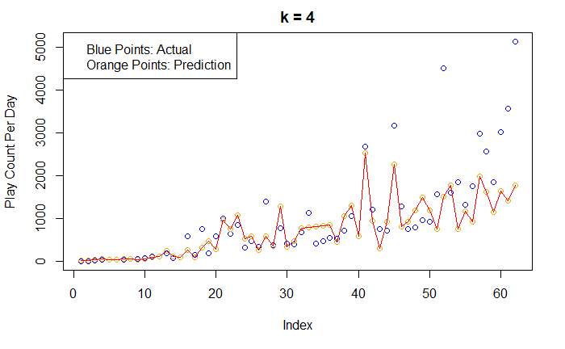

```r
lines(pred.with.k.4$pred, col = "red")
legend(x = "topleft",legend = c("Blue Points: Actual","Orange Points: Prediction"))
```

From the graph we can see that with knn perform rather well when playcount per day is low but perform rather poorly when the numbers are high. To evaluate the fitness of our data, we can find Mean Absolute Error (MAE) and the Mean Squared Error (MSE) when k = 4

```r
find.mae <- function(vec1,vec2) {
  return (sum(abs(vec1 - vec2)) / length(vec1))
}
find.mse <- function(vec1,vec2) {
  return (sum((vec1 - vec2)^2) / length(vec1))
}
pred.with.k.4 <- knn.reg(training.no.id,validation.no.id, y = playcount_per_day, k = 4)
pred.with.k.4.mae <- find.mae(pred.with.k.4$pred,validation.no.id$playcount_per_day)
pred.with.k.4.mse <- find.mse(pred.with.k.4$pred,validation.no.id$playcount_per_day)
pred.with.k.4.mae
```

```
[1] 411.4425
```

```r
pred.with.k.4.mse
```

```
[1] 581947
```

To see if we can improve by choosing a better k, we can try more k from 1 to 20

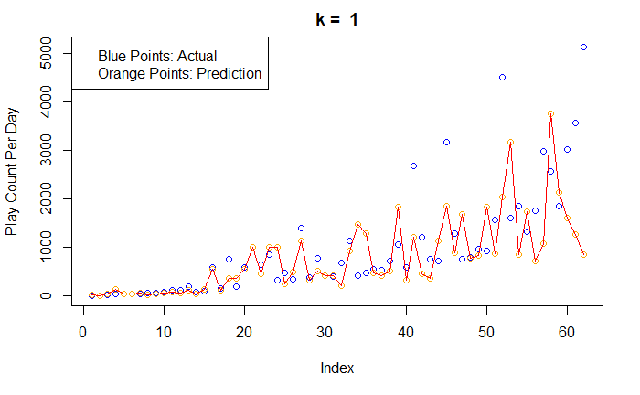

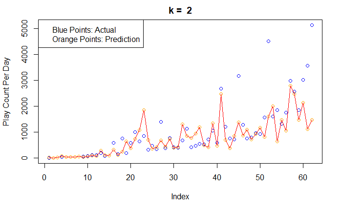

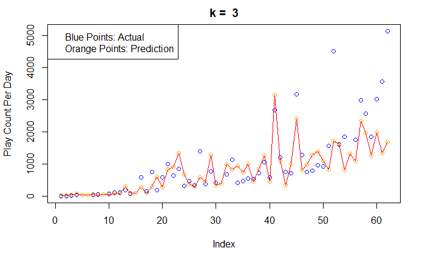

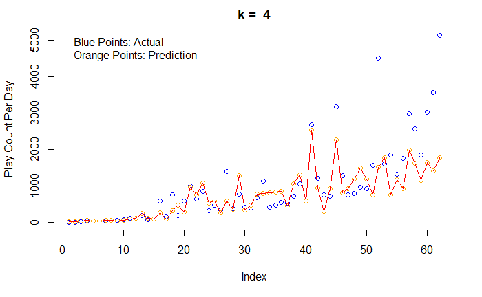

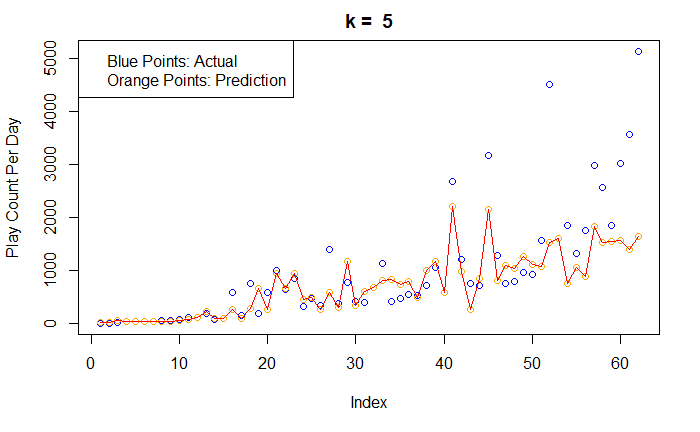

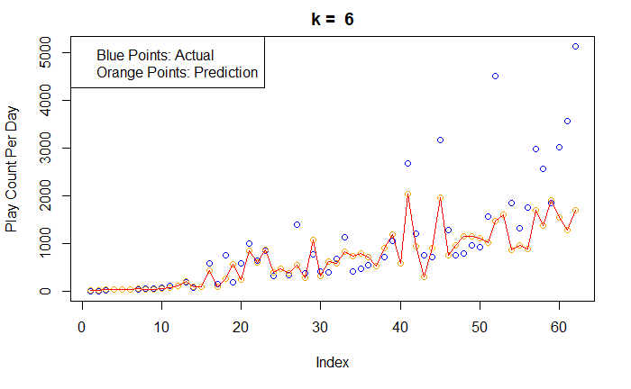

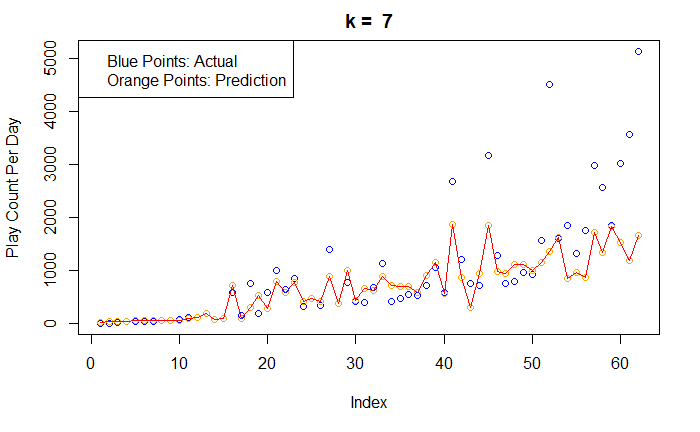

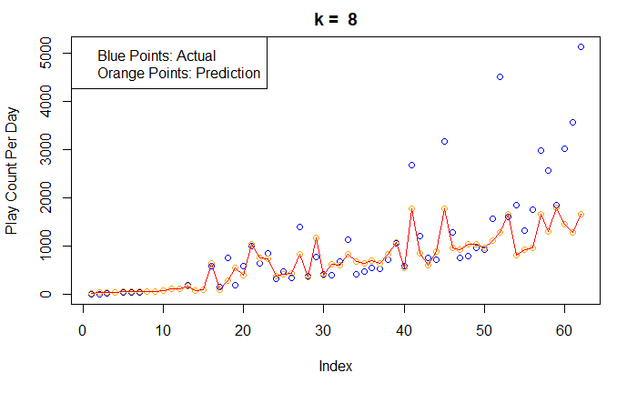

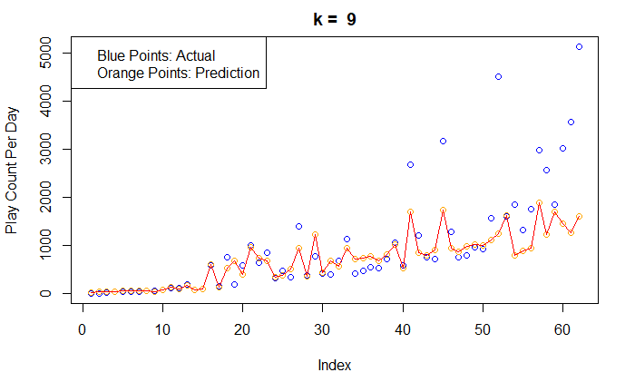

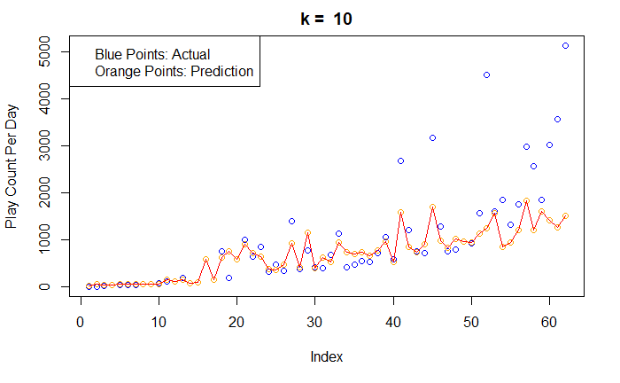

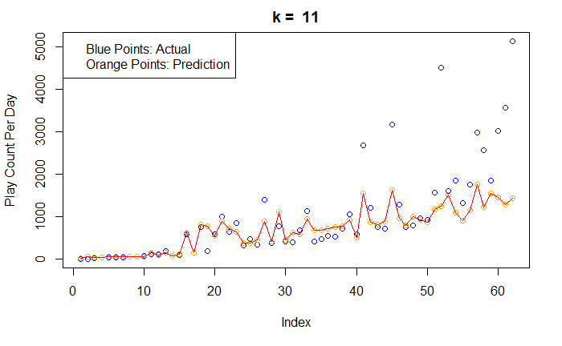

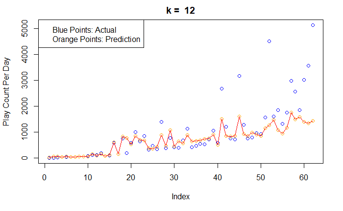

[8 more figures not shown]

```r
for (i in 1:20) {
  pred.with.different.k <- knn.reg(training.no.id,validation.no.id,y=playcount_per_day, k = i)
  plot(validation.no.id$playcount_per_day, col = "blue", ylab = "Play Count Per Day", main = paste("k = ",i))
  points(pred.with.different.k$pred, col = "orange")
  lines(pred.with.different.k$pred, col = "red")
  legend(x="topleft",legend = c("Blue Points: Actual","Orange Points: Prediction"))
}
```

We notice a trend that when k > 5 there is not much difference except the line gets tighter and tighter. We and take a closer look at how different k performs by looking at their mean absolute error and mean squared error

```r
k.values <- seq(1,5)
pred.with.k.1 <- knn.reg(training.no.id,validation.no.id, y = playcount_per_day, k = 1)
pred.with.k.1.mae <- find.mae(pred.with.k.1$pred,validation.no.id$playcount_per_day)
pred.with.k.1.mse <- find.mse(pred.with.k.1$pred,validation.no.id$playcount_per_day)
pred.with.k.2 <- knn.reg(training.no.id,validation.no.id, y = playcount_per_day, k = 2)
pred.with.k.2.mae <- find.mae(pred.with.k.2$pred,validation.no.id$playcount_per_day)
pred.with.k.2.mse <- find.mse(pred.with.k.2$pred,validation.no.id$playcount_per_day)
pred.with.k.3 <- knn.reg(training.no.id,validation.no.id, y = playcount_per_day, k = 3)
pred.with.k.3.mae <- find.mae(pred.with.k.3$pred,validation.no.id$playcount_per_day)
pred.with.k.3.mse <- find.mse(pred.with.k.3$pred,validation.no.id$playcount_per_day)
pred.with.k.5 <- knn.reg(training.no.id,validation.no.id, y = playcount_per_day, k = 5)
pred.with.k.5.mae <- find.mae(pred.with.k.5$pred,validation.no.id$playcount_per_day)
pred.with.k.5.mse <- find.mse(pred.with.k.5$pred,validation.no.id$playcount_per_day)
k.comparison.dataframe <- data.frame(k.values,c(pred.with.k.1.mae,pred.with.k.2.mae,pred.with.k.3.mae,pred.with.k.4.mae,pred.with.k.5.mae),
                                     c(pred.with.k.1.mse,pred.with.k.2.mse,pred.with.k.3.mse,pred.with.k.4.mse,pred.with.k.5.mse))
names(k.comparison.dataframe) <- c("k value","Mean Absolute Error","Mean Squared Error")
k.comparison.dataframe
```

| k value | Mean Absolute Error | Mean Squared Error |
| --- | --- | --- |
| 1 | 525.7266 | 851988.7 |
| 2 | 418.5491 | 640164.3 |
| 3 | 399.2707 | 540523.0 |
| 4 | 411.4425 | 581947.0 |
| 5 | 398.7196 | 594506.4 |

Even though k = 5 has a slightly beeter MAE than k = 3, k = 3 has a much better MSE, partly because by having a smaller k allows for a higher variance which allows it to do a better job at predicting data with play count per day that are higher than usual. Therefore we think k = 3 is the best k

Let’s take a look at a different model, a multiple regression model.

As we discovered in data exploration, our data is positive skewed which means we should probably apply some transformation that can make play count per day sufficiently normalized. Here we experiment different types of transformation and try to find which performs the best

```r
natural.log.transformed.playcount.per.day <- log(well.shaped.dataframe.no.outlier$playcount_per_day)
log10.transformed.playcount.per.day <- log10(well.shaped.dataframe.no.outlier$playcount_per_day)
square.root.transformed.playcount.per.day <- (well.shaped.dataframe.no.outlier$playcount_per_day)^(1/2)
cube.root.transformed.playcount.per.day <- (well.shaped.dataframe.no.outlier$playcount_per_day)^(1/3)
par(mfrow=c(3,2))
hist(well.shaped.dataframe.no.outlier$playcount_per_day, xlab = "Play Count Per Day", main = "Original Distribution")
hist(natural.log.transformed.playcount.per.day, xlab = "Natural Log Play Count Per Day", main = "Natural Log Transformed Distribution")
```

```r
hist(log10.transformed.playcount.per.day, xlab = "log10 Play Count Per Day", main = "Log 10 Transformed Distribution")
hist(square.root.transformed.playcount.per.day,  xlab = "Square Root Play Count Per Day", main = "Square Root Transformed Distribution")
```

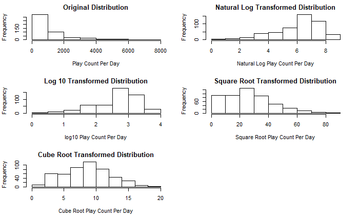

```r
hist(cube.root.transformed.playcount.per.day, xlab = "Cube Root Play Count Per Day", main = "Cube Root Transformed Distribution")
```

Judging from the graph, the cube root transformation is clearly the one that best normalize our data, therefore we are going to cube root transform our play count per day in our training and validation set

```r
cube.root.transformed.training <- training.no.id
cube.root.transformed.training$playcount_per_day <- (training.no.id$playcount_per_day) ^ (1/3)
cube.root.transformed.training
```

|  | hit_length | diff_size | diff_overall | diff_approach | diff_drain | max_combo | difficultyrating | bpm | favourite_count | approved_ranked | genre_anime | genre_pop | language_japanese | playcount_per_day |
| --- | --- | --- | --- | --- | --- | --- | --- | --- | --- | --- | --- | --- | --- | --- |
| 1 | 215 | 3.0 | 3.0 | 5.0 | 3.0 | 511 | 1.523502 | 115.000 | 0 | 0 | 0 | 0 | 0 | 1.216440 |
| 2 | 224 | 3.1 | 2.0 | 3.0 | 2.0 | 684 | 1.490454 | 182.000 | 21 | 0 | 0 | 0 | 1 | 1.310371 |
| 4 | 109 | 3.5 | 4.0 | 5.0 | 4.0 | 412 | 2.320535 | 210.000 | 12 | 0 | 0 | 0 | 0 | 1.889882 |
| 5 | 113 | 2.8 | 2.0 | 3.0 | 3.0 | 323 | 1.659627 | 210.000 | 12 | 0 | 0 | 0 | 0 | 1.889882 |
| 6 | 225 | 3.0 | 4.0 | 5.0 | 3.0 | 892 | 2.183076 | 182.000 | 21 | 0 | 0 | 0 | 1 | 1.889882 |
| 7 | 173 | 2.5 | 3.0 | 3.0 | 3.0 | 284 | 1.501699 | 78.000 | 1 | 0 | 0 | 0 | 0 | 2.080084 |
| 8 | 32 | 3.0 | 2.0 | 3.0 | 3.0 | 97 | 1.477244 | 171.000 | 0 | 0 | 1 | 0 | 0 | 1.930979 |
| 9 | 32 | 3.5 | 4.0 | 5.0 | 4.0 | 120 | 2.066566 | 171.000 | 0 | 0 | 1 | 0 | 0 | 1.930979 |
| 10 | 232 | 3.0 | 3.0 | 3.0 | 2.0 | 556 | 1.527961 | 160.000 | 2 | 0 | 0 | 0 | 1 | 2.080084 |
| 11 | 102 | 3.0 | 4.0 | 5.5 | 3.0 | 352 | 1.872148 | 155.000 | 3 | 0 | 0 | 0 | 1 | 2.289428 |

[output cut: 421 more lines]

```r
cube.root.transformed.validation <- validation.no.id
cube.root.transformed.validation$playcount_per_day <- (validation.no.id$playcount_per_day) ^ (1/3)
cube.root.transformed.validation
```

|  | hit_length | diff_size | diff_overall | diff_approach | diff_drain | max_combo | difficultyrating | bpm | favourite_count | approved_ranked | genre_anime | genre_pop | language_japanese | playcount_per_day |
| --- | --- | --- | --- | --- | --- | --- | --- | --- | --- | --- | --- | --- | --- | --- |
| 3 | 215 | 3.5 | 5.0 | 6.5 | 4.0 | 653 | 2.592210 | 115.000 | 0 | 0 | 0 | 0 | 0 | 1.754411 |
| 12 | 113 | 3.0 | 2.0 | 3.0 | 2.0 | 318 | 1.540548 | 178.000 | 22 | 0 | 0 | 1 | 1 | 2.080084 |
| 19 | 228 | 4.5 | 9.0 | 9.0 | 7.5 | 1271 | 5.862358 | 182.000 | 21 | 0 | 0 | 0 | 1 | 2.506649 |
| 28 | 116 | 3.3 | 3.0 | 2.0 | 2.0 | 314 | 1.922309 | 96.000 | 12 | 0 | 0 | 0 | 0 | 3.207534 |
| 35 | 93 | 3.0 | 4.0 | 4.0 | 2.0 | 237 | 1.567382 | 160.000 | 14 | 0 | 1 | 0 | 1 | 3.301927 |
| 44 | 113 | 3.9 | 8.0 | 9.0 | 6.0 | 534 | 4.667369 | 178.000 | 22 | 0 | 0 | 1 | 1 | 3.245952 |
| 51 | 112 | 4.0 | 8.2 | 9.0 | 6.0 | 523 | 4.722546 | 178.000 | 22 | 0 | 0 | 1 | 1 | 3.356067 |
| 60 | 121 | 4.3 | 8.6 | 9.3 | 6.5 | 1073 | 5.308002 | 210.000 | 12 | 0 | 0 | 0 | 0 | 3.881968 |
| 67 | 112 | 4.0 | 8.3 | 9.2 | 5.0 | 548 | 5.047137 | 178.000 | 22 | 0 | 0 | 1 | 1 | 3.737290 |
| 76 | 85 | 3.5 | 6.0 | 8.0 | 5.0 | 547 | 3.276604 | 259.000 | 31 | 0 | 0 | 0 | 0 | 4.125207 |

[output cut: 52 more lines]

Now we can build our multiple linear regression model

```r
multiple.linear.regression.model.initial <- lm(formula = playcount_per_day ~ .,data = cube.root.transformed.training)
summary(multiple.linear.regression.model.initial)
```

```
Call:
lm(formula = playcount_per_day ~ ., data = cube.root.transformed.training)

Residuals:
    Min      1Q  Median      3Q     Max
-5.7734 -1.1042 -0.1382  0.9765  8.4116

Coefficients:
                    Estimate Std. Error t value Pr(>|t|)
(Intercept)        3.9350940  0.9300770   4.231 2.86e-05 ***
hit_length        -0.0153562  0.0032360  -4.745 2.86e-06 ***
diff_size         -0.4469013  0.2426939  -1.841  0.06627 .
diff_overall       0.0958334  0.1760207   0.544  0.58643
diff_approach      0.4677224  0.1687315   2.772  0.00582 **
diff_drain         0.0796568  0.1441513   0.553  0.58084
max_combo          0.0011530  0.0005815   1.983  0.04805 *
difficultyrating  -0.2507583  0.1754721  -1.429  0.15374
bpm               -0.0066401  0.0028935  -2.295  0.02224 *
favourite_count    0.0140852  0.0009917  14.203  < 2e-16 ***
approved_ranked    4.8704566  0.2254349  21.605  < 2e-16 ***
genre_anime       -0.1715462  0.2318204  -0.740  0.45972
genre_pop         -0.2521527  0.3251894  -0.775  0.43854
language_japanese  0.9487080  0.2220639   4.272 2.40e-05 ***
---
Signif. codes:  0 *** 0.001 ** 0.01 * 0.05 . 0.1   1

Residual standard error: 1.909 on 417 degrees of freedom
Multiple R-squared:  0.728, Adjusted R-squared:  0.7195
F-statistic: 85.84 on 13 and 417 DF,  p-value: < 2.2e-16
```

To improve our model we can use backward fitting. This means the first variable we should remove is diff_overall

```r
multiple.linear.regression.model.second <- lm(formula = playcount_per_day ~ . - diff_overall,data = cube.root.transformed.training)
summary(multiple.linear.regression.model.second)
```

```
Call:
lm(formula = playcount_per_day ~ . - diff_overall, data = cube.root.transformed.training)

Residuals:
    Min      1Q  Median      3Q     Max
-5.7621 -1.0987 -0.1673  0.9568  8.3859

Coefficients:
                    Estimate Std. Error t value Pr(>|t|)
(Intercept)        3.8696532  0.9215010   4.199 3.27e-05 ***
hit_length        -0.0153483  0.0032332  -4.747 2.84e-06 ***
diff_size         -0.4256082  0.2393202  -1.778 0.076064 .
diff_approach      0.5238287  0.1334932   3.924 0.000102 ***
diff_drain         0.0920806  0.1422138   0.647 0.517677
max_combo          0.0011555  0.0005810   1.989 0.047376 *
difficultyrating  -0.2127332  0.1608382  -1.323 0.186674
bpm               -0.0067890  0.0028781  -2.359 0.018791 *
favourite_count    0.0141015  0.0009904  14.238  < 2e-16 ***
approved_ranked    4.8699247  0.2252430  21.621  < 2e-16 ***
genre_anime       -0.1574273  0.2301714  -0.684 0.494381
genre_pop         -0.2276542  0.3217900  -0.707 0.479674
language_japanese  0.9376812  0.2209522   4.244 2.71e-05 ***
---
Signif. codes:  0 *** 0.001 ** 0.01 * 0.05 . 0.1   1

Residual standard error: 1.908 on 418 degrees of freedom
Multiple R-squared:  0.7278,    Adjusted R-squared:   0.72
F-statistic: 93.13 on 12 and 418 DF,  p-value: < 2.2e-16
```

The next feature with highest p-value is diff_drain

```r
multiple.linear.regression.model.third <- lm(formula = playcount_per_day ~ . - diff_overall -diff_drain,data = cube.root.transformed.training)
summary(multiple.linear.regression.model.third)
```

```
Call:
lm(formula = playcount_per_day ~ . - diff_overall - diff_drain,
    data = cube.root.transformed.training)

Residuals:
    Min      1Q  Median      3Q     Max
-5.8333 -1.0918 -0.1778  0.9489  8.3812

Coefficients:
                    Estimate Std. Error t value Pr(>|t|)
(Intercept)        3.8758576  0.9208123   4.209 3.14e-05 ***
hit_length        -0.0149567  0.0031739  -4.712 3.34e-06 ***
diff_size         -0.3949135  0.2344153  -1.685   0.0928 .
diff_approach      0.5761439  0.1061906   5.426 9.79e-08 ***
max_combo          0.0010536  0.0005589   1.885   0.0601 .
difficultyrating  -0.2114807  0.1607151  -1.316   0.1889
bpm               -0.0071321  0.0028269  -2.523   0.0120 *
favourite_count    0.0140928  0.0009896  14.241  < 2e-16 ***
approved_ranked    4.8798636  0.2245635  21.730  < 2e-16 ***
genre_anime       -0.1549182  0.2299792  -0.674   0.5009
genre_pop         -0.2247960  0.3215367  -0.699   0.4849
language_japanese  0.9452274  0.2204916   4.287 2.25e-05 ***
---
Signif. codes:  0 *** 0.001 ** 0.01 * 0.05 . 0.1   1

Residual standard error: 1.906 on 419 degrees of freedom
Multiple R-squared:  0.7275,    Adjusted R-squared:  0.7204
F-statistic: 101.7 on 11 and 419 DF,  p-value: < 2.2e-16
```

The features with the highest p-value right now are genre_anime and genre_pop but since they are categorical variable we choose not to remove it and move on to the next highest feature with the higher p-value: difficultyrating

```r
multiple.linear.regression.model.fourth <- lm(formula = playcount_per_day ~ . - diff_overall -diff_drain -difficultyrating,data = cube.root.transformed.training)
summary(multiple.linear.regression.model.fourth)
```

```
Call:
lm(formula = playcount_per_day ~ . - diff_overall - diff_drain -
    difficultyrating, data = cube.root.transformed.training)

Residuals:
    Min      1Q  Median      3Q     Max
-5.9361 -1.0628 -0.1787  0.9208  8.4245

Coefficients:
                    Estimate Std. Error t value Pr(>|t|)
(Intercept)        4.0131533  0.9156783   4.383 1.48e-05 ***
hit_length        -0.0136324  0.0030127  -4.525 7.88e-06 ***
diff_size         -0.4161114  0.2340647  -1.778  0.07617 .
diff_approach      0.4756479  0.0738461   6.441 3.25e-10 ***
max_combo          0.0007190  0.0004981   1.443  0.14966
bpm               -0.0074551  0.0028187  -2.645  0.00848 **
favourite_count    0.0138723  0.0009762  14.211  < 2e-16 ***
approved_ranked    4.8955647  0.2244415  21.812  < 2e-16 ***
genre_anime       -0.1372525  0.2297869  -0.597  0.55063
genre_pop         -0.2419883  0.3215508  -0.753  0.45213
language_japanese  0.9364824  0.2205833   4.245 2.69e-05 ***
---
Signif. codes:  0 *** 0.001 ** 0.01 * 0.05 . 0.1   1

Residual standard error: 1.908 on 420 degrees of freedom
Multiple R-squared:  0.7264,    Adjusted R-squared:  0.7199
F-statistic: 111.5 on 10 and 420 DF,  p-value: < 2.2e-16
```

```r
multiple.linear.regression.model.fifth <- lm(formula = playcount_per_day ~ . - diff_overall -diff_drain -difficultyrating -diff_size -max_combo,data = cube.root.transformed.training)
summary(multiple.linear.regression.model.fifth)
```

```
Call:
lm(formula = playcount_per_day ~ . - diff_overall - diff_drain -
    difficultyrating - diff_size - max_combo, data = cube.root.transformed.training)

Residuals:
    Min      1Q  Median      3Q     Max
-5.8525 -1.0717 -0.1955  0.9351  8.2130

Coefficients:
                    Estimate Std. Error t value Pr(>|t|)
(Intercept)        2.4456052  0.6137472   3.985 7.96e-05 ***
hit_length        -0.0102405  0.0015669  -6.535 1.83e-10 ***
diff_approach      0.4531321  0.0431376  10.504  < 2e-16 ***
bpm               -0.0059510  0.0027030  -2.202   0.0282 *
favourite_count    0.0140013  0.0009741  14.374  < 2e-16 ***
approved_ranked    4.8633530  0.2248744  21.627  < 2e-16 ***
genre_anime       -0.2282246  0.2270145  -1.005   0.3153
genre_pop         -0.3317514  0.3183513  -1.042   0.2980
language_japanese  0.9362443  0.2176734   4.301 2.11e-05 ***
---
Signif. codes:  0 *** 0.001 ** 0.01 * 0.05 . 0.1   1

Residual standard error: 1.915 on 422 degrees of freedom
Multiple R-squared:  0.7229,    Adjusted R-squared:  0.7177
F-statistic: 137.6 on 8 and 422 DF,  p-value: < 2.2e-16
```

Now that our model has R-square > 0.70 and all non-categorical features have p value < 0.05, we can start using this model and see how well it works against the validation set. Since we cubed root transformed our predicting variable, we will backtransform by raising the result to the power of 3

```r
multiple.linear.regression.model.prediction <- predict(multiple.linear.regression.model.fifth,cube.root.transformed.validation)
multiple.linear.regression.model.prediction.backtransformed <-(multiple.linear.regression.model.prediction) ^ 3
multiple.linear.regression.model.prediction.backtransformed
```

```
          3          12          19          28          35          44          51          60          67          76          83
  15.716746   15.644921   81.528610    5.458157   34.570757  142.224749  143.063458   81.686097  150.630025   68.565717   94.987752
         92          99         108         115         124         131         140         147         156         163         172
 105.541459   90.842888  173.140299 1031.981580 1247.605761 1071.455228  668.969290  165.518698 1100.020002  699.770380 1189.111912
        179         188         195         204         211         220         227         236         243         252         259
 912.188858  716.986749  625.982004  626.887269 1361.166722  760.488758  525.474386  620.562328 1255.181550  838.534557  831.269996
        268         275         284         291         300         307         316         323         332         339         348
 601.511046  203.374242  785.802687  553.736349  892.816538  784.700115  773.604438 1252.854427  995.839780  748.736153  640.114209
        355         364         371         380         387         396         403         412         419         428         435
1472.457331 1238.509023 1481.582460 1224.355710  946.691913  226.822830 1490.676308 1383.858466 1284.287047  792.386831 1323.917074
        444         451         460         467         476         485         495
1746.753013 1289.300845 1368.088309 1247.816737  664.684483 1727.110427 1746.753013
```

```r
plot(validation.no.id$playcount_per_day, ylab = "playcount_per_day", main = "Multiple Linear Regression Model", col = "blue")
points(multiple.linear.regression.model.prediction.backtransformed, col="orange")
```

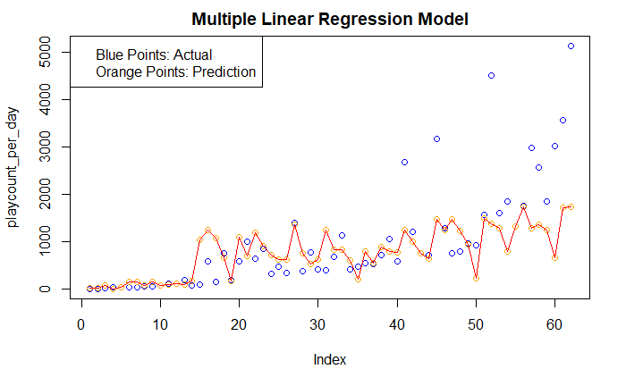

```r
lines(multiple.linear.regression.model.prediction.backtransformed, col="red")
legend(x="topleft",legend = c("Blue Points: Actual","Orange Points: Prediction"))
```

To evaluate how good our model is we use a similar metric to the ones we used to evaluate kNN regression model (MAE and MSE)

```r
multiple.linear.regression.model.mae <- find.mae(multiple.linear.regression.model.prediction.backtransformed,validation.no.id$playcount_per_day)
multiple.linear.regression.model.mse <- find.mse(multiple.linear.regression.model.prediction.backtransformed,validation.no.id$playcount_per_day)
multiple.linear.regression.model.mae
```

```
[1] 486.0669
```

```r
multiple.linear.regression.model.mse
```

```
[1] 755687
```

Comparing between the kNN regression model and the multiple linear regression model, we think the kNN regression model is the superior one. This is because the multiple linear regression model have a much higher MAE and MSE. Not only so, multiple linear regression suffers when the dataset is small which is true in our case. Furthermore, kNN makes no assumption of the distribution of the data, so no transformations are needed and accuracy can be improved.

However, this does not mean the multiple linear regression model is not useful, in fact, we can see what propoerties would make a beatmap popular thanks to the coefficients that multiple linear regression model brought up:

```r
multiple.linear.regression.model.fifth$coefficients
```

```
      (Intercept)        hit_length     diff_approach               bpm   favourite_count   approved_ranked       genre_anime
      2.445605215      -0.010240520       0.453132073      -0.005951028       0.014001336       4.863353014      -0.228224623
        genre_pop language_japanese
     -0.331751376       0.936244301
```

If we order by coefficients, we can see that the most popular properties of a beatmap are:

approved_ranked -> language_japanese -> diff_approach -> favourite_count

and the most negative influential properties of a beatmaps ordered from least influence to most influence are:

bpm -> hit_length -> genre_anime -> genre_pop

Intepretation of the positive properties:

In osu! there are many approval status, being simply approved, qualified, or ranked. To rank a beatmap it has to go through a lot of inspection and re-editing, which means ranked beatmaps usually have higher quality than the others. The osu! website also has its default beatmap page filtered by beatmaps that are ranked, which might also contribute to ranked beatmaps having high play count per day.

Traditionally, there have been a lot of overlap between the osu community and the anime community, and since most anime music are in japanese, it is natural that beatmap made from japanese song are more popular than the others.

diff_approach refers to a mechanic in the game that is called “approach rate”, which indicates how fast the ring appraoches the circle. From this we can see that players seem to enjoy beatmaps with higher approach rate than lower.

favorite_count refers to the number of players that marked the beatmap as favorite, it seems like the more player that mark a beatmap as a favorite, the more likely that some other player would like to play.

Intepretation of the negative properties:

bpm stands for beats per minute, a high bpm means the song is fast and vice versa. From this we can see that people seem to enjoy beatmaps that are slower rather than faster.

hit_length stands for the time between the first hit object appears and the last hit object appears, it can be roughly translated to the length of the song. From this we find that player tend to enjoy beatmaps that are shorter than the others.

genre_anime and genre_pop: Although from the coefficient it seem like players really do not enjoy anime or pop song, the p value for these two faetures are around 0.3 which is way above the convention 0.05. Therefore these two features shouldn’t be considered as factors that would affect the popularity of a beatmap.

In conclusion,

The “ideal beatmap” to a player, or a beatmap that would gain the most play count per day, would have the following property: – is ranked – is in japanese – has a high approach rate – has been liked by other players – is a slower song – is short

In fact, the most played beatmap in osu so far, aside from the default song, is a beatmap based on a song named “No Title” by Reol, and it matches 5 out of the 6 properties.

– is ranked (check) – is in japanese (check) – has a high approach rate (9.6 / 10, check) – has been liked by other players (check) – is a slower song (bpm is 200 which is higher than the average of 167, Not check) – is short (only 70 seconds, below average 141 seconds, check)